# A Guide to Reliability: Avoiding Misconceptions

Derek Briggs

1/26/2020

# Motivation for this Document

For the past 14 years or so I’ve taught the concept of reliability to graduate students as part of a educational measurement sequence here are the University of Colorado. Beyond formal readings, the materials I’ve given students to help them study have typically consisted of powerpoint slides. While I think the content on those slides has gotten better and better over time, I think the R Markdown format is a far superior format because of the way it allows one to integrate narrative and empirical demonstrations in a single place. The other push came from a special focus article and commentaries on reliability I helped out together when I was still the editor of *Educational Measurement: Issues and Practice* in 2015.

My hope is that the “learning module” that follows will build on these articles and thereby serve as a useful resource in developing a deep understanding of both the concept of reliability, and ways that this concept can be parameterized and estimated.

# Introduction

Reliability is one of the most important concepts in measurement. Let’s start with the intuition behind reliability for measurements taken in the physical sciences. The concept of reliability is premised on replication. It goes something like this: say I devise a measurement procedure. By procedure, I mean a set of steps that need to be taken in order produce a measure of some attribute of interest for a given object of interest. The procedure culminates in a numeric value. When we ask about the reliability of the value, we are essentially asking how likely we would be to observe the same value if the measurement procedure were to be replicated. But this raises some thorny questions. If we replicate the procedure, what stays fixed and what varies? Time, for instance, cannot be fixed, but can we treat the passage of time as irrelevant to the procedure? What about the instrument used to take the measure, is that fixed? What about the person operating the instrument? What about other conditions, such as the location where the measurement procedure is taking place? The object being measured?

You can see already that what it is we mean when speak of “reliability” depends greatly on being clear about the conditions of measurement and, conceptually, what is and is not being replicated. This is certainly true in the context of physical measurement, and equally true in educational and psychological measurement.

The concept of reliability in psychometrics has it origins in what is known as *True Score Theory* (also referred to as *Classical Test Theory*). True score theory is really a means to an end: it provides a mathematical basis to operationalize the concept of reliability into a model parameter. This parameter is a reliability coefficient, something that can be estimated from data. In what follows I will try to take you through this derivation, but I’m going to take the liberty of borrowing from the conceptual toolbox of *Generalizability Theory* (Cronbach et al, 1972).

# True Score Theory

## Preliminaries

Let’s start with a “test” score, $X$, associated with a test-taker, indexed by the subscript $j$. A test in this context consists of some fixed number of items, and the responses to these items are given ordinal scores. (In this sense we can also consider an attitudinal survey to be a type of test). So if we then let the subscript $i$ index a test item, then

$$X_j= \sum_{i=1}^{n_i} X_{ij}$$
where $n_i$ represents the total number of items on the test.

In much of what you are going to see in the derivation of the true score theory model, test items are going to disappear from view: the theory occurs at the level of a test score, where a test score is computed as either a sum or average across items. But in order to make sense of the concept of “measurement error”, it’s really important to be able to think of the existence of a hypothetical “universe” of items that *could* have been placed on the test. (This is an instance when I’m borrowing from Generalizability Theory.) In this sense, the $n_i$ that happen to be on a given test are just a random sample from a universe of $I$ items. We could just as easily have created a test comprised of $n^\prime_i$ items, and if we did, we’d expect the two tests to be *parallel* in the sense that they should be equally difficult, on average, and that the test scores should have the same variance, on average. So there are two sources of chance variability that influence the value we observe for $X_{ij}$: the sampling of test-takers from some population of test-takers, and the sampling of items from some universe of items.

## The Within-Person Model

For each test-taker, let’s assume that an observed test score is a linear function of a “true score” and “error”

$$\tag{1}X_j = \tau_j + e_j$$
Each person’s true score, $\tau_j$, is the expected value taken over all possible tests of $n_i$ items that could be constructed by sampling at random (with replacement) from the universe of possible test items.

$$\tag{2}E(X_j)=\tau_j$$
and the “error” term simply represents the difference between a person’s observed score and the (unknown) true score

$$\tag{3}e_j=X_j-E(X_j)$$
Note that $\tau_j$ and $e$ are independent, and therefore uncorrelated, by definition. This represents an untestable assumption, something that cannot be falsified with data.

Now, what we’d really like to know about, for each test-taker ($j$), is the sampling distribution of test scores we would observe if it were possible to have the person take tests with different sets of items over and over again, but after each administration we “brainwash”" the person to forget the experience.

Let’s consider the hypothetical example of two students, Derek and Ben. Both take a vocabulary test consisting of 10 items. How would there scores (number of items correct out of 10) vary if they took 200 vocabulary tests, each time with a different random sample of items? (I’m just picking 200 tests out of the air here because I need a finite value to simulate data; I could just as well have picked 1000 or 10000000–this has no impact on the point I’m about to make.)

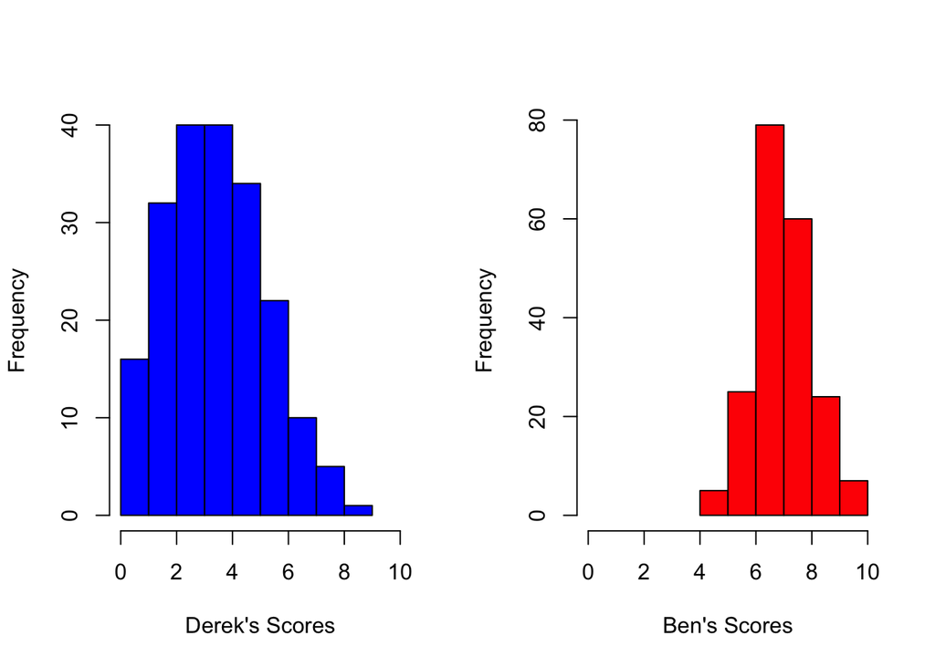

```r
library(msm)
set.seed(8971)
derek<-rtnorm(200,3.3,2,lower=0,upper=10)
derek<-round(derek,digits=1)
set.seed(1234)
ben<-rtnorm(200,7.1,1,lower=0,upper=10)
ben<-round(ben,digits=1)
par(mfrow=c(1,2))
hist(derek,xlim=range(0,10),main='',col="blue",xlab="Derek's Scores")
hist(ben,xlim=range(0,10),breaks=c(4:10),main='',col="red",xlab="Ben's Scores")
```

Two things to notice here.

1. Derek’s true score (3.3) is lower than Ben’s true score (7.1)
2. The variability in Derek’s scores (SD=2) is twice as big as that for Ben’s scores (SD=1)

We can formalize this result by turning back to the fundamental equation of true score theory, $X_j = \tau_j + e_j$. If we are interested in the sampling variance of observed scores for each case $j$, we want

$$\sigma^2_{X_j}=\sigma^2_{\tau_j}+\sigma^2_{e_j}$$
since $\tau_j$ and $e_j$ are independent. But since $\tau_j$ is a constant, this expression reduces to

$$\sigma^2_{X_j}=\sigma^2_{e_j}$$
In words, for each case, variance in observed scores across replications of the measurement procedure is caused solely by error variance.

Let Derek represent case 1 ($j=1$), and Ben represent case 2 ($j=2$). In our hypothetical example, $\sigma_{e_1}>\sigma_{e_2}$, which means that not only is Derek’s true score lower than Ben’s true score, it is measured with more error than Ben’s.

## Conceptual Issues

This raises two questions.

1. What is the cause of measurement error in this scenario?

One typical answer to this is to point to idiosyncratic unpredictable features of the testing experience that can effect test-takers differently (e.g., getting a good or bad night of sleep, happening to sit next to someone with a distracting cough). I guess this is possible, but it doesn’t seem very consistent with the thought experiment that would give rise to a distribution of scores for each test-taker. The only thing that is clearly changing in each replication of the measurement procedure is the set of items to which a test-taker is being exposed. Everything else about the testing experience stays constant–the day, the time of day, the surrounding environment, etc. These things still might have an impact on a student’s performance, but they would become part of the student’s true score (biasing it up or down).

In my view, the only clear source of “error variance” in this context comes in the interaction between a test-taker and the particular set of items included on the test. Think of it this way: if any 10 item test is a random sample from a universe of possible items we could have used on the test, then just by chance, on any given test some people will see items that happen to be easier for them, and some will see items that happen to be harder for them. (Example: On one test a student get a vocabulary item that happens to be something that was in a book she read for fun over the summer, on another test she doesn’t.) So what we mean by measurement error is a positive or negative bump in an observed score that can be attributed to a person’s good or bad luck in the items that happen to be on the test when it is administered.

2. Why would measurement error be bigger or smaller for certain test-takers?

Well, measurement error might be related to a test-takers true score–maybe it’s bigger for students with low true scores, and lower for students with high true scores. Who knows? This is a nice transition to the heart of true score theory: *we have no good way to get person-specific estimates of measurement error*. The problem is that we can’t actually observe within-person distributions of observed scores because (a) we can’t administer an infinite (or even a very large) number of tests with different random sets of items, and (b) even if we could, the test scores wouldn’t be independent. Test-takers might tire, or they might learn as they go. So the strategy we take in true score theory is to formulate a model at the population level, use this to compute a reliability coefficient, and then use this reliability coefficient to back out an estimate of average measurement error for a given measurement procedure.

## Reliability

We are going to express the fundamental equation of true score theory for a population of test-takers as

$$\tag{4}X = T + E$$
This time, we are taking the variance not over replications within each individual test-taker, but *across* the observed scores of all individual test-takers.

$$\tag{5}\sigma^2_{X}=\sigma^2_{T}+\sigma^2_{E}$$
Recall that when the model was within-person, each person’s true score was a constant ($\tau_j$). But here, since we are taking variance *across* people, it is not. Also, $\sigma^2_{E}$ can be thought of as $E[\sigma^2_{e_j}]$

To be as concrete as I can here, let’s go back to our hypothetical vocabulary test that Derek and Ben have taken. Derek and Ben were part of a sample of 100 students that took this test. The average score on this test was 6.4 with a standard deviation of 1.5.

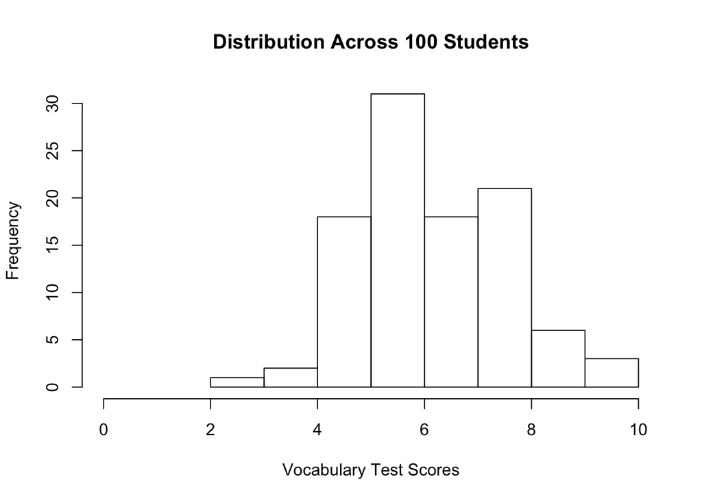

```r
library(msm)
set.seed(345)
x<-rtnorm(100,6.4,1.5,lower=0,upper=10)
x<-round(x,digits=1)
hist(x,xlim=range(0,10),main="Distribution Across 100 Students",
     xlab="Vocabulary Test Scores")
```

The variability we observe in these scores is caused by *both* true differences among students, and by measurement error. So this brings us–finally–to the concept of reliability.

$$\tag{6}\rho^2_{XT}=\frac{\sigma^2_{XT}}{\sigma^2_{X}\sigma^2_{T}}$$

In words, reliability is the proportion of obsereved score variance that is true score variance. Another, more mathematical interpretation, is that reliability is the squared correlation between observed scores and true scores. Here are three mathematically equivalent formulations of the concept

$$\rho^2_{XT}=\frac{\sigma^2_{T}}{\sigma^2_{X}}=\frac{\sigma^2_{T}}{\sigma^2_{T}+\sigma^2_{E}}=1-\frac{\sigma^2_{E}}{\sigma^2_{X}}$$

## Parallel Test Forms

It is crucial to appreciate that so far what we have done is establish a model that relates observed test scores to true scores and error, and then used this relationship to formulate what it means to have a test that produces reliable scores. What we have at this point is the parameter of interest, $\rho^2_{XT}$. What we need is a way to get a good estimate of this parameter, since we can’t directly observe either $\sigma^2_{T}$ or $\sigma^2_{E}$.

To do this, we need to introduce something that was alluded to above, and that is the notion of *parallel test forms*.

Let $X$ and $X^\prime$ represent two different test forms. The two test forms are parallel so long as $E(X)=E(X^\prime)=T$ and $\sigma^2_{X} = \sigma^2_{X^\prime}$. This means that the two forms are equivalent in difficulty and have the same observed score variance.

What if we compute the correlation of scores across the common population taking the two test forms? This correlation would be

$$\rho_{XX^\prime}=\frac{\sigma_{XX^\prime}}{\sigma_{X}\sigma_{X^\prime}}$$
Recall that $X = T + E$ and $X^\prime = T + E^\prime$, so we can rewrite the expression above as
$$\rho_{XX^\prime}=\frac{\sigma_{(T+E)(T+E^\prime)}}{\sigma_{X}\sigma_{X^\prime}},$$
$$\rho_{XX^\prime}=\frac{\sigma_{TT}+\sigma_{TE}+\sigma_{TE^\prime}+\sigma_{EE^\prime}}{\sigma_{X}\sigma_{X^\prime}}.$$
By assumption of the model, true scores and error scores are uncorrelated, and error scores are uncorrelated across parallel forms. So this expression reduces to

$$\rho_{XX^\prime}=\frac{\sigma_{TT}}{\sigma_{X}\sigma_{X^\prime}}.$$
Now the covariance between true scores is just the variance of true scores, so $\sigma_{TT}=\sigma^2_{T}$. And we defined parallel forms to have equal observed score variance, so $\sigma_{X}=\sigma_{X^\prime}$ and $\sigma_{X}\sigma_{X^\prime}=\sigma^2_{X}$. This means that

## The Spearman-Brown Formula

The Spearman-Brown “prophecy” formula can be use to predict the reliability of a test that consists of a composite from two smaller tests of the same length (i.e., same number of items).

$$\tag{8}\rho_{XX^\prime}=\frac{2\rho_{YY^\prime}}{1+\rho_{YY^\prime}}$$
In the expression above, the composite test score $X=Y_1+Y_2$, and we define $Y_1$ and $Y_2$ to be parallel. So $X=Y+Y^\prime$. Think of $\rho_{YY^\prime}$ as the “old” reliability of a test and $\rho_{XX^\prime}$ as the “new” reliability we would predict if the test doubled in length.

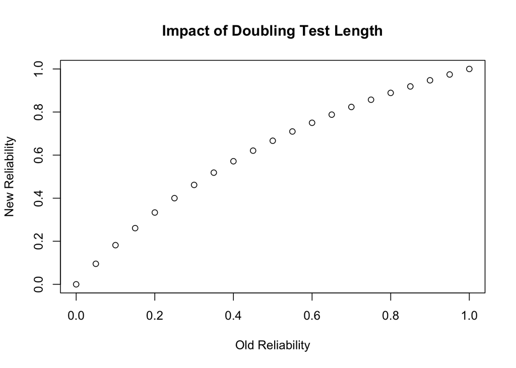

```r
rel.old<-seq(from=0, to=1,by=.05)
rel.new<-2*rel.old/(1+rel.old)
plot(rel.old,rel.new,xlab="Old Reliability",ylab="New Reliability",
     main="Impact of Doubling Test Length")
```

Notice the nonlinear relationship. As base reliability increases, doubling the number of items is predicted to have less of an impact on the reliability of the new test.

So here is a strategy for getting an estimate of reliability if you only have a single test administration.

1. Split the test into two parallel halves
2. Correlate the scores on each half
3. Use the Spearman-Brown formula to get an estimate for reliability if the test was twice as long.

Here is the formula for the *generalized Spearman-Brown prophecy*:

$$\tag{9}\rho_{XX^\prime}=\frac{k\rho_{YY^\prime}}{1+(k-1)\rho_{YY^\prime}}$$
This formula indicates how reliability is predicted to increase for any factor $k$ increase in the number of items on the test. We’ll come back to the relationship between number of items and reliability again in the next section.

# Cronbach’s Alpha

A problem with estimating reliability by splitting one test into two parallel forms is that it may not be obvious which split to use. Cronbach’s alpha solves this problem by providing an estimate which can be interpreted as the average of all possible ways the test could be split into two forms and correlated, corrected for the restriction in test length. Here’s the formula:

$$\tag{10}\alpha = \frac{m}{m-1} \left(1-\frac{\sum_{i=1}^{m}S^2_{X_i}}{S^2_{X}} \right)$$
It is often typical to see this same formula with $\sigma^2_{X_i}$ in place of $S^2_{X_i}$ and $\sigma^2_{X}$ in place of $S^2_{X}$. Here I’m using the notation found in Davenport et al (2015) where they use $S$ in place of $\sigma^2$, probably to make the point that $\alpha$ is always an estimate based on computations using sample data.

OK, let’s unpack the equation for $\alpha$ by focusing first on the ratio inside the parenthesis.

1. The denominator, $S^2_{X}$ represents the variance of the composite test score we get by adding together all the items on the test. Since each item can be thought of as a random variable (recall the notion that each test is a random sample from a universe of possible items), it follows that $S^2_{X}=\sum_{i=1}^{m}\sum_{j=1}^{m}S_{X_iX_j}$. What this means is that the variance of the composite is the sum of all the item variances and item covariances. If there are $m$ items, then variance of the sum of these items equals the sum of $m^2$ variance and covariance terms.
2. The numerator, $\sum_{i=1}^{m}S^2_{X_i}$, represents the sum of all $m$ item variances. What it does *not* include are the item covariances.
- When the ratio $\frac{\sum_{i=1}^{m}S^2_{X_i}}{S^2_{X}}$ is small, this implies that the covariance between test items is large.
- When the ratio $\frac{\sum_{i=1}^{m}S^2_{X_i}}{S^2_{X}}$ is large, this implies that the covariance between test items is small.

So, when items on a test are all moderately to strongly correlated with each other, this is an indication of internal consistency. Since $\alpha$ has a functional relationship to item intercorrelations, it is often referred to as an estimate of the internal consistency of a test. Unfortunately, as we’ll see in just a but, this is a bit misleading, but let’s first focus on things you can do with an estimate of reliability using $\alpha$.

## Uses of Reliability Coefficients

In what follows, I want to focus on useful things you can do once you have an estimate of reliability. I’m going to illustrate this for the case where your estimate for reliability is based on $\alpha$ as presented above, but all the same applications work if you have decided to use a different statistic as an estimator.

### To Disattenuate a Correlation

It was this use that actually motivated Charles Spearman to first estimate a reliability coefficient in 1904. When two variables are measured with error, the correlation between them will be attenuated by measurement error (it will be lower than it would be if they were both measured without error). If we have estimates of reliability for each variable, then we can get a disattenuated estimate of the correlation.

Let $\hat{X} = X + E$ and $\hat{Y} = Y + E$

If we have $\rho(\hat{X},\hat{Y})$, and we also know $\alpha_X$ and $\alpha_Y$, then

$$\rho(X,Y)=\frac{\rho(\hat{X},\hat{Y})}{\sqrt{{\alpha_X}{\alpha_Y}}}$$

### To Estimate the Standard Error of Measurement

To a great extent, having a reliability coefficient is a means to an end–quantifying measurement error. Once you know the reliability of a sample of test scores (e.g., $\alpha$) along with the standard deviation of the test scores ($S_{X}$), you can easily compute the standard error of measurement:

$$SEM=\sqrt{1-\alpha}S_{X}$$
You can play with this formula a bit, and if you do, you’ll see that as $\alpha$ goes up, the SEM will go down and vice versa. For example, let’s say you have a standardized test score variable with a mean of 0 and an SD of 1. If $\alpha=.9$, then $SEM=\sqrt{.1}=.32$. On the other and, if $\alpha=.5$, then $SEM=\sqrt{.5}=.71$.

### To Estimate True Scores

Let $x_j$ represent the test score for individual j and $\bar{x}$ represent the mean test score taken over all individual test-takers. We can get an estimate of individual j’s true score using the following expression

$$\tau_j={\alpha}{x_j}+({1-\alpha}){\bar{x}}$$
This is known as *Kelley’s Equation* after Truman Kelley who originated it. Notice how this works. If $\alpha$ is high, we place more weight on an individuals observed test score as an estimate of his or her true score. If $\alpha$ is low, we place more weight on the mean test score for the full sample of individuals (an estimate for the population mean) as an estimate of his or her true score.

## Common Misconceptions about Cronbach’s Alpha

### Alpha = internal consistency

Recall that when we unpacked the expression for $\alpha$ based on eqn 10, we came to appreciate that the total variance of a composite test score was being decomposed into two pieces, the sum of each unique item variance and the sum of all item covariances. Just so you don’t need to scroll back, here’s that expression for eqn 10 once again:

$$\tag{10}\alpha = \frac{m}{m-1} \left(1-\frac{\sum_{i=1}^{m}S^2_{X_i}}{S^2_{X}} \right)$$

If we just looked at the term in the parenthesis, then yes, it is reasonable to say that this term provides an indication of internal consistency, in these sense that the closer it is to 1, the more we can conclude that total variability in the composite score, ${S^2_{X}}$, is being driven by predominantly by interitem correlations. That said, notice that it still doesn’t reveal whether *all* the item pairs have the same interitem correlation, so even in this sense it provides a limited indication of “consistency”. But the key idea here is to appreciate that $\alpha$ is not just computed on the basis of the term in parenthesis, but also involves the number of items. So $\alpha$ is at least *related* to internal consistency. But it is not identical to it.

To illustrate this, in their 2015 article, Davenport, Davison, Liu & Love (2015) [DDLL] make the simplifying assumption that all items have a variance of 1. When this is the case, it follows that $S^2_{X}=m+m(m-1)\bar{r}$. Where $\bar{r}$ represents the average correlation among items. (For details on this derivation, see p. 5)

Now we see another way to write $\alpha$ that is mathematically equivalent to eqn 1 (under the assumption that all items have a variance of 1):

$$\tag{11}\alpha=\frac{m\bar{r}}{1+(m-1)\bar{r}}$$
Notice that this is almost exactly the same as the generalized Spearman-Brown formula. We see from this more clearly the central impact that the number of items, $m$, has on $\alpha$. Indeed, no matter what the average interitem correlaton, $\bar{r}$, so long as new items maintain this same average interitem correlation, you can attain any desired value for $\alpha$ by increasing the number of items on a test.

With a little algebra, we can also rewrite equation 11 so that we can solve directly for the number of items needed to attain a target reliability, given a fixed $\bar{r}$:

$$m=\frac{\alpha_{d}(1-\bar{r})}{\bar{r}(1-\alpha_{d})}$$
where $\alpha_{d}$ stands for “desired” alpha.

Again, the important thing to appreciate from this is that reliability, as estimated using $\alpha$ is not solely a function of internal consistency.

### Alpha as an index of unidimensionality

Another common misconception about $\alpha$ is that it can be used as an index of unidimensionality. Before we see why this is a misconception, let’s recall a key ingredient we typically use to assess the dimensionality of some set of indicator variables in a principal component analysis, eigenvalues. In this case test items = indicator variables. Given some set of $m$ items, we use eigenvalues to re-express the total variance in our $m$ by $m$ correlation matrix into $m$ orthogonal variables such that each successive eigenvalue explains only variance that could not be explained by the previous eigenvalue. When performing a principal components analysis, we analyze the observed correlation matrix, so each item has a variance of 1 along the main diagonal. The total variance is an orthogonal re-expression of the correlation matrix, and will be equivalent to the total number of indicator variables, $m$. Let $\lambda_1$ represent the first eigenvalue extracted from a PCA. The total variance explained by the first eigenvalue is

$$V=\frac{\lambda_1}{m}$$

DDLL, citing a result from Friedman & Weisberg (1981), note that $\lambda_1$ is approximately a function of $\bar{r}$: $\lambda_1 \approx 1+(m-1)\bar{r}$. Given this, DDLL point out a way that $\alpha$ can be approximated:

$$\tag{12}\alpha \approx \frac{\bar{r}}{V}$$
What this implies is that it is possible for $\alpha$ to be close to 1 so long as $\bar{r}$ is about the same as $V$. DDLL provide three made-up examples where $\alpha$ would provide misleading information if used as an index of unidimensionality. In two cases, $\alpha$ is large (.91, .81) even though the data is clearly multidimensional; in another case, $\alpha$ is small (.09) even though there is evidence of one (albeit weak) common factor.

## An Empirical Example

For this example I’m going to use data from a test I give to first year doctoral students in the University of Colorado’s School of Education that attempts to measure the construct of 80s Music Fluency. I have data on 46 students who took my 20 item test. Each item consists of the first 30 seconds of a song that was a top 10 hit from the 1980s. An item is scored as correct (1) if the student can name the title of the song or the artist. Otherwise it is scored as incorrect (0).

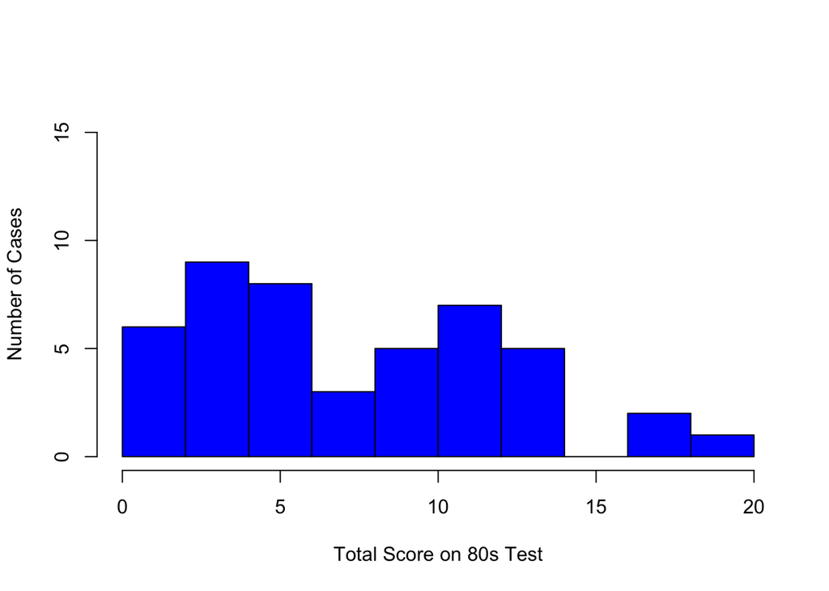

Some descriptive stats for the total score on the test

```r
summary(total)
```

```
##    Min. 1st Qu.  Median    Mean 3rd Qu.    Max.
##   1.000   3.000   6.500   7.674  11.000  19.000
```

It should be clear that the 80s music fluency of my students left a lot to be desired!

### Using the function alpha

```r
library("psych")
x<-alpha(d)
round(x$total$std.alpha,3)
```

```
## [1] 0.873
```

```r
round(x$total$raw_alpha,3)
```

```
## [1] 0.873
```

```r
round(x$total$average_r,3)
```

```
## [1] 0.256
```

Let’s start by looking at the overall results.

The alpha function returns three key statistics relevant to the presentation this far:

1. std.alpha = standardized alpha and is equivalent to equations 10 and 11 above when each item has been standardized to have a common variance of 1.
2. raw.alpha = alpha computed using equation 5 in DDLL, which is $\alpha=\frac{m\frac{\bar{c}}{s^2}}{1+\left(m-1\right)\frac{\bar{c}}{s^2}}$
3. average_r = average interitem correlation, $\bar{r}$

In this example, the std.alpha value is 0.873 and the raw.alpha value is 0.873. The average_r is 0.256.

We can also get item-specific information. The table below provides, for each item, the correlation between each item and the total score (both with and without the item included in the total score) as well and the mean (equivalent to proportion correct since these items are dichotomously scored) and sd for each item.

```r
round(x$item.stats[4:7],digits=3)
```

```
##             r.cor r.drop  mean    sd
## J.Cougar    0.635  0.594 0.652 0.482
## Flock       0.546  0.493 0.348 0.482
## TTD         0.561  0.493 0.217 0.417
## Wham        0.636  0.572 0.261 0.444
## Marley      0.340  0.297 0.283 0.455
## Madonna     0.236  0.198 0.717 0.455
## Metallica   0.520  0.459 0.326 0.474
## Tone.Loc    0.527  0.482 0.500 0.506
## Big.Country 0.692  0.645 0.283 0.455
## DM          0.446  0.403 0.283 0.455
## Erasure     0.599  0.540 0.196 0.401
## U2          0.452  0.406 0.739 0.444
## Bon.Jovi    0.648  0.610 0.457 0.504
## Cure        0.373  0.330 0.217 0.417
## Idol        0.574  0.522 0.500 0.506
## Band.Aid    0.420  0.365 0.130 0.341
## Def.Leppard 0.694  0.642 0.304 0.465
## Schilling   0.470  0.417 0.109 0.315
## MJ          0.442  0.395 0.630 0.488
## Prince      0.626  0.587 0.522 0.505
```

The alpha function also provides other information I’m not going to get into here, such as the impact on $\alpha$ if an item were dropped from the scale.

Let’s go ahead and apply DDDL’s equation 3 (my equation 11) above

$$\alpha=\frac{m\bar{r}}{1+(m-1)\bar{r}}$$

to show that it gives the same reliability estimate we get using the alpha function.

```r
m<-ncol(d)
rbar<-x$total$average_r
round(m*rbar/(1+(m-1)*rbar),3)
```

```
## [1] 0.873
```

Same result!

Now let’s see if we can “approximate” $\alpha$ using $\alpha \approx \frac{\bar{r}}{V}$. We already know $\bar{r}$, but we need to find $V$. In keeping with the definition of $V$, we need to extract the first principal component from the item correlation matrix and express this as a proportion of total variance.

```r
fpc<-principal(d,nfactors=1)
V<-fpc$values[1]/ncol(d)
round(V,3)
```

```
## [1] 0.306
```

```r
round(rbar/V,3)
```

```
## [1] 0.834
```

Let’s have a closer look at the dimensionality of this 80s music test.

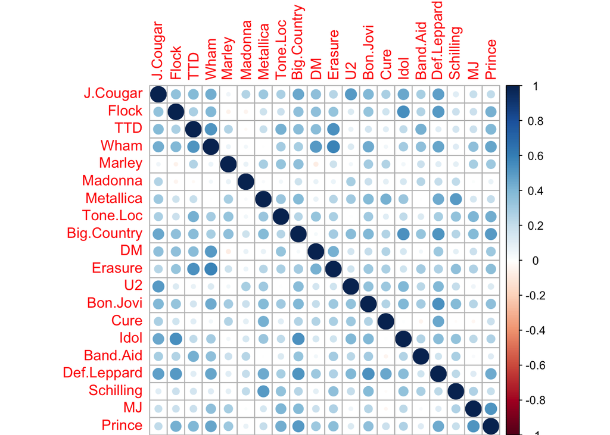

```r
library(corrplot)
corrplot(cor(d))
```

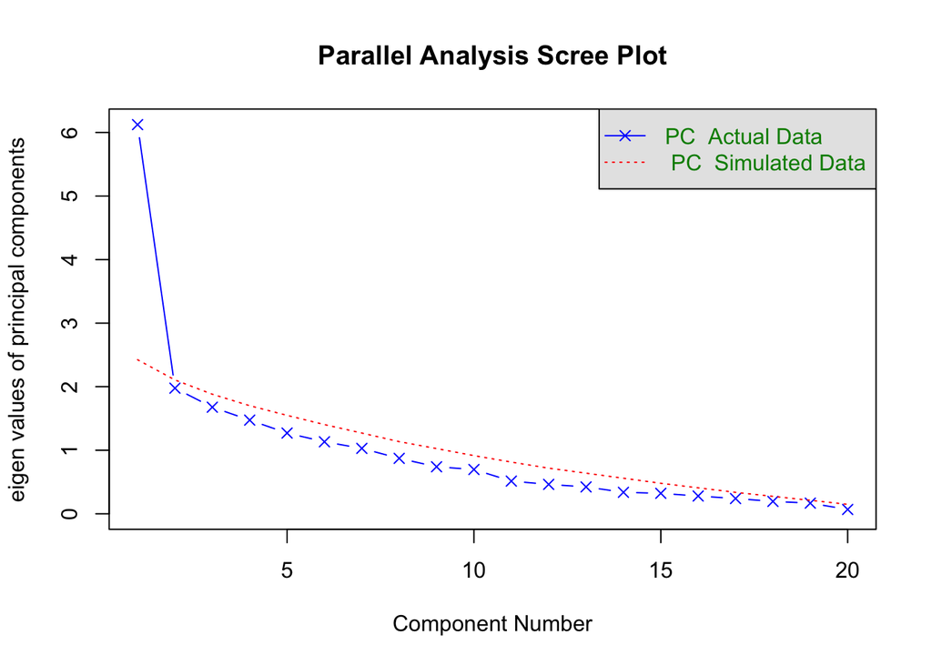

```
## Parallel analysis suggests that the number of factors =  NA  and the number of components =  1
```

```r
cm<-cor(d)
fa.parallel(cm, n.obs = nrow(d),fm="pa", fa="pc",
       main = "Parallel Analysis Scree Plot",
        n.iter=100,error.bars=FALSE,ylabel=NULL,show.legend=TRUE)
```

The results seem to suggest we will do pretty well with a single factor solution.

# Reliability from a Factor Analytic Point of View

Note: This section gets a bit more technical than the sections above and assumes prior exposure readings and/or coursework in factor analysis or structural equation modeling.

It’s important to understand that $\alpha$, something we can compute, is not necessarily the same thing as $\rho_{XT}$. Instead, it is a *lower bound* to $\rho_{XX^\prime}$. This means that $\alpha \leq \rho_{XX^\prime}$. For a proof that shows why $\alpha$ should be regarded as a lower bound, see Novick & Lewis (1967), pages 4-6. In fact, in their 1967 article, Novick & Lewis note that alpha is not necessarily even the best lower bound estimate. The first person to point this up and establish the concept of “lower bound” for reliability was Louis Guttman, (see Guttman, 1945; 1953). It was in Guttman (1943) that he first derived from we are now calling Cronbach’s alpha

This raises an obvious question: when will $\alpha = \rho_{XX^\prime}$?

## Essential Tau Equivalence

To answer this question, Novick & Lewis (1967) introduce the concept of *essential tau equivalence*. Essential tau equivalence means that the expected value for each item on a test (where the expectation is taken over the population of respondents) will be a linear transformation with a fixed slope and a varying intercept. To express this mathematically, consider any two test items, $X_g$ and $X_h$. Each item has been sampled from the same universe of items eligible for inclusion on the test in question. For each item, we posit that the fundamental equation of classical test theory holds, so we can write $X_g = T_g + E_g$ and $X_h = T_h + E_h$. Now consider expressing the true score for one item as a linear function of the other:

$$T_g = a_{gh} + b_{gh}T_{h}$$
*If the two items are *tau equivalent*, $a_{gh}=0$ and $b_{gh}=1$.* If the two item are *essentially tau equivalent*, $a_{gh}$ can vary but $b_{gh}=1$.

In other words, for tau equivalence to hold at the item level, it must be the case that all items have the same difficulty and the same intercorrelation.

Essential tau equivalence relaxes the assumption that pairs of items need to have the same difficulty, but does require them to have the same intercorrelation. When essential tau equivalence holds between all items on a test, the average correlation between items is the same thing as the correlation between *any* two items. When essential tau equivalence holds, $\alpha = \rho_{XX^\prime}$.

Of course, essential tau equivalence is a pretty restrive assumption, but it is an assumption that is, in principle at least, testable through the specification of a confirmatory factor analysis (CFA) model, an approach favored by Green & Yang (2015) who show how $\alpha$ can be computed directly from the estimates of a one a factor CFA model with restrictions placed on all item loadings. In other words, this means a model in which there is a single factor and all items have the same loading on this factor.

Green & Yang present an equation (#10 on p. 15 of their 2015 article) that can be used to compute $\alpha$ following the specification and estimation of a one factor CFA with a common loading and items that have been standardized to have a variance of 1.

$$\tag{13}\rho_{XX^\prime} = \alpha = \frac{J^2\lambda^2}{\sigma^2_{X}}$$
where $J$ = number of test items, and $\lambda$ represents a common factor loading. The numerator = variance in test items caused by the common factor. Think of the $J$ by $J$ variance-covariance matrix. Under the assumption of essential tau equivalence, each element of this model-implied matrix is $\lambda^2$. So total variance explained by the common factor is just ${J^2\lambda^2}$.

The denominator, $\sigma^2_{X}$ represents total variance in the $J$ items. But we don’t get an estimate for this by finding the variance of the observed total score after summing over the items. Instead, we get this from the model, such that $\hat{\sigma}^2_X = J^2\lambda^2 + Je$, where $e=1-\lambda^2$.

## Continuing Empirical Example using CFA

Let’s return to estimation of the reliability of our 80s test. Instead of estimating $\alpha$ using equation 10 and observed item scores, we can instead fit the essential tau equivalence model using the function cfa from the package lavaan, and then compute equation 13.

One thing that complicates this approach is that factor analysis assumes that indicator variables have a continuous distribution, and that each variable has a linear relationship with one or more latent factors. Let’s see what happens if we ignore this for our items and just conduct a 1-factor CFA using default maximum likelihood estimation. One preliminary step I’m going to take here is to standardize all the items.

```r
library("lavaan")
means<-apply(d,2,mean)
sd<-apply(d,2,sd)
d.std<-scale(d,center=means,scale=sd)
tau_mod <- '
general =~
lambda*J.Cougar + lambda*Flock +
lambda*TTD + lambda*Wham + lambda*Marley +
lambda*Madonna + lambda*Metallica +
lambda*Tone.Loc + lambda*Big.Country +
lambda*DM + lambda*Erasure +
lambda*U2 + lambda*Bon.Jovi + lambda*Cure +
lambda*Idol + lambda*Band.Aid + lambda*Def.Leppard +
lambda*Schilling +lambda*MJ + lambda*Prince'
taumod <- cfa(model = tau_mod, data = d.std, std.lv = TRUE)
out<-lavInspect(taumod,what="est")
parameterEstimates(taumod)[1:20,1:6]
```

```
##        lhs op         rhs  label   est    se
## 1  general =~    J.Cougar lambda 0.519 0.061
## 2  general =~       Flock lambda 0.519 0.061
## 3  general =~         TTD lambda 0.519 0.061
## 4  general =~        Wham lambda 0.519 0.061
## 5  general =~      Marley lambda 0.519 0.061
## 6  general =~     Madonna lambda 0.519 0.061
## 7  general =~   Metallica lambda 0.519 0.061
## 8  general =~    Tone.Loc lambda 0.519 0.061
## 9  general =~ Big.Country lambda 0.519 0.061
## 10 general =~          DM lambda 0.519 0.061
## 11 general =~     Erasure lambda 0.519 0.061
## 12 general =~          U2 lambda 0.519 0.061
## 13 general =~    Bon.Jovi lambda 0.519 0.061
## 14 general =~        Cure lambda 0.519 0.061
## 15 general =~        Idol lambda 0.519 0.061
## 16 general =~    Band.Aid lambda 0.519 0.061
## 17 general =~ Def.Leppard lambda 0.519 0.061
## 18 general =~   Schilling lambda 0.519 0.061
## 19 general =~          MJ lambda 0.519 0.061
## 20 general =~      Prince lambda 0.519 0.061
```

```r
round((fitmeasures(taumod)[c("chisq","df","pvalue","chisq.scaled",
"df.scaled","pvalue.scaled","cfi","gfi","tli","rmsea",
"rmsea.pvalue","srmr")]),3)
```

```
##        chisq           df       pvalue         <NA>         <NA>
##      289.534      189.000        0.000           NA           NA
##         <NA>          cfi          gfi          tli        rmsea
##           NA        0.648        0.651        0.646        0.108
## rmsea.pvalue         srmr
##        0.000        0.147
```

Applying eqn 13 to results:

```r
J<-ncol(d)
lambda<-out$lambda[1]
e<-1-lambda^2
rel<-(J^2*lambda^2)/((J^2*lambda^2)+J*e)
round(rel,3)
```

```
## [1] 0.88
```

So we get about the same estimate for reliability as we did using Cronbach’s alpha. If the model fits the data, we can say that this estimate is not a lower bound to $\rho_{XX^\prime}$, but is an unbiased estimate of it. But does the model fit the data? It doesn’t look like it.

*The standardized mean residual is 0.1473517.* The RMSEA is 0.1075342. *The CFI is 0.6481458.

How would our estimate of reliability change is we used polychoric correlations instead?

```r
tau_modp <- '
general =~
lambda*J.Cougar + lambda*Flock +
lambda*TTD + lambda*Wham + lambda*Marley +
lambda*Madonna + lambda*Metallica + lambda*Tone.Loc +
lambda*Big.Country +lambda*DM + lambda*Erasure +
lambda*U2 + lambda*Bon.Jovi + lambda*Cure +
lambda*Idol + lambda*Band.Aid + lambda*Def.Leppard
+ lambda*Schilling +lambda*MJ + lambda*Prince'
artists<-names(d)
taumodp <- cfa(model = tau_modp, data = d, ordered = artists ,
               estimator = "DWLS", se = "robust",
               test = "scaled.shifted", std.lv = TRUE)
outp<-inspect(taumod,what="std")
parameterEstimates(taumodp)[1:20,1:6]
```

```
##        lhs op         rhs  label   est    se
## 1  general =~    J.Cougar lambda 0.713 0.043
## 2  general =~       Flock lambda 0.713 0.043
## 3  general =~         TTD lambda 0.713 0.043
## 4  general =~        Wham lambda 0.713 0.043
## 5  general =~      Marley lambda 0.713 0.043
## 6  general =~     Madonna lambda 0.713 0.043
## 7  general =~   Metallica lambda 0.713 0.043
## 8  general =~    Tone.Loc lambda 0.713 0.043
## 9  general =~ Big.Country lambda 0.713 0.043
## 10 general =~          DM lambda 0.713 0.043
## 11 general =~     Erasure lambda 0.713 0.043
## 12 general =~          U2 lambda 0.713 0.043
## 13 general =~    Bon.Jovi lambda 0.713 0.043
## 14 general =~        Cure lambda 0.713 0.043
## 15 general =~        Idol lambda 0.713 0.043
## 16 general =~    Band.Aid lambda 0.713 0.043
## 17 general =~ Def.Leppard lambda 0.713 0.043
## 18 general =~   Schilling lambda 0.713 0.043
## 19 general =~          MJ lambda 0.713 0.043
## 20 general =~      Prince lambda 0.713 0.043
```

```r
round((fitmeasures(taumodp)[c("chisq","df","pvalue","chisq.scaled",
      "df.scaled","pvalue.scaled","cfi","gfi","tli","rmsea",
      "rmsea.pvalue","srmr")]),3)
```

```
##         chisq            df        pvalue  chisq.scaled     df.scaled
##       215.849       189.000         0.088       207.589       189.000
## pvalue.scaled           cfi           gfi           tli         rmsea
##         0.168         0.976         0.856         0.976         0.056
##  rmsea.pvalue          srmr
##         0.385         0.232
```

```r
J<-ncol(d)
lambdap<-outp$lambda[1]
ep<-1-lambdap^2
relp<-(J^2*lambdap^2)/((J^2*lambdap^2)+J*ep)
round(relp, 3)
```

```
## [1] 0.898
```

So using polychoric correlations, the estimate for reliability goes up, though not by a lot. Interestingly, two of our three key indices of model fit have improved a lot

*The change in standardized mean residual is 0.0851393.

*The change in RMSEA is -0.051348.

*The change in CFI is 0.3282134.

## A Congeneric Model

We can relax the assumption of essential tau equivalence and specify instead what is know as a *congeneric model*. This allows both the intercept and slope to vary for each item, but still assumes a one factor solution.

```r
con_mod <- '
general =~
J.Cougar + Flock +TTD + Wham + Marley + Madonna +
Metallica + Tone.Loc + Big.Country + DM + Erasure +
U2 + Bon.Jovi + Cure + Idol + Band.Aid + Def.Leppard +
Schilling + MJ + Prince'
artists<-names(d)
conmod <- cfa(model = con_mod, data = d, ordered = artists
    ,estimator = "DWLS", se = "robust", test = "scaled.shifted", std.lv = TRUE)
parameterEstimates(conmod)[1:20,]
```

```
##        lhs op         rhs   est    se      z pvalue ci.lower ci.upper
## 1  general =~    J.Cougar 0.821 0.106  7.730  0.000    0.613    1.029
## 2  general =~       Flock 0.725 0.116  6.246  0.000    0.497    0.952
## 3  general =~         TTD 0.764 0.103  7.455  0.000    0.563    0.965
## 4  general =~        Wham 0.853 0.075 11.415  0.000    0.706    0.999
## 5  general =~      Marley 0.434 0.181  2.396  0.017    0.079    0.790
## 6  general =~     Madonna 0.291 0.176  1.652  0.099   -0.054    0.636
## 7  general =~   Metallica 0.670 0.123  5.446  0.000    0.429    0.911
## 8  general =~    Tone.Loc 0.656 0.123  5.348  0.000    0.416    0.897
## 9  general =~ Big.Country 0.869 0.077 11.324  0.000    0.718    1.019
## 10 general =~          DM 0.618 0.137  4.530  0.000    0.351    0.886
## 11 general =~     Erasure 0.806 0.120  6.698  0.000    0.570    1.042
## 12 general =~          U2 0.624 0.133  4.693  0.000    0.363    0.885
## 13 general =~    Bon.Jovi 0.779 0.101  7.723  0.000    0.582    0.977
## 14 general =~        Cure 0.516 0.174  2.970  0.003    0.176    0.857
## 15 general =~        Idol 0.765 0.103  7.444  0.000    0.564    0.967
## 16 general =~    Band.Aid 0.598 0.170  3.523  0.000    0.265    0.930
## 17 general =~ Def.Leppard 0.854 0.083 10.252  0.000    0.691    1.017
## 18 general =~   Schilling 0.706 0.178  3.967  0.000    0.357    1.055
## 19 general =~          MJ 0.619 0.132  4.672  0.000    0.359    0.878
## 20 general =~      Prince 0.820 0.087  9.452  0.000    0.650    0.990
```

```r
round((fitmeasures(conmod)[c("chisq","df","pvalue","chisq.scaled","df.scaled",
                             "pvalue.scaled","cfi","gfi","tli","rmsea",
                             "rmsea.pvalue","srmr")]),3)
```

```
##         chisq            df        pvalue  chisq.scaled     df.scaled
##       132.178       170.000         0.986       180.332       170.000
## pvalue.scaled           cfi           gfi           tli         rmsea
##         0.279         1.000         0.912         1.037         0.000
##  rmsea.pvalue          srmr
##         0.999         0.183
```

Notice that this model shows evidence of better fit in terms of some statistics relative to the constrained model with polychoric correlations, but with this illustrative example we have to be careful about these sorts of interpetations given our very small sample. Notice that the SRMR is still extremely high.

*The change in standardized mean residual is -0.0492082.

*The change in RMSEA is -0.0561862.

*The change in CFI is 0.0236408.

To complete the example, having fit this model we can now use the more general formula Green & Yang provide for estimating reliability as the sum of item communalities over total item covariance (communalities + uniqueness). See equation 7 from Green & Yang.

```r
pe <- parameterestimates(conmod)
sumT <- sum(pe[1:15, "est"])^2
sume <- sum(pe[61:75, "est"])
sumX <- sumT+sume
round(sumT/sumX, 3)
```

```
## [1] 0.874
```

So fitting the congeneric model doesn’t significantly change the interpretation one gets about the reliability of these test scores. Maybe not that surprising when you see that the variability in loading estimates when we relax the equality constraint is not that great.

# References

Cronbach, L. J. (1951). Coefficient alpha and the internal structure of tests. Psychometrika, 15, 297-334.

Cronbach, L. J., Gleser, G. C., Nanda, H., & Rajaratnam, N. (1972). The dependability of behavioral measurements: Theory of generalizability of scores and profiles. New York: John Wiley.

Daveport et al (2015) Reliability, dimensionality, and internal consistency as defined by Cronbach: Distinct albeit related concepts. Educational Measurement: Issues & Practice. Vol. 34, No. 4, pp. 4–9.

Davenport, E. C., Davison, M. L., Liou, P.-Y., & Love, Q. U. (2016). Easier said than done: Rejoinder on Sijtsma and on Green and Yang. Educational Measurement: Issues and Practice, 35(1), 6–10.

Friedman, S., & Weisberg, H. F. (1981). Interpreting the first eigenvalue of a correlation matrix. Educational and Psychological Measure- ment, 41, 11–21.

Guttman, L. (1945). A basis for analyzing test-retest reliability. Psychometrika, 10, 255-282.

Guttman, L. (1953). Reliability formulas that do not assume experimental independence. Psychometrika, 18, 225-239.

Green, S. & Yang, Y. (2015). Evaluation of dimensionality in the assessment of internal consistency reliability: Coefficient alpha and omega coefficients. Educational Measurement: Issues & Practice. Vol. 34, No. 4, pp. 14–20.

Novick, M. R., & Lewis, C. (1967). Coefficient alpha and the reliability of composite measurements. Psychometrika, 32(1), 1-13.

Sijtsma, K. (2015). Delimiting coefficient alpha from internal consistency and unidimensionality. Educational Measurement: Issues & Practice. Vol. 34, No. 4, pp. 10-13.

# Further Resources

Brennan, R. (2001). Generalizability Theory. New York: Springer-Verlag.

Green, S. B., Lissitz, R. W., & Mulaik, S. A. (1977). Limitations of coefficient alpha as an index of test unidimensionality. Educational and Psychological Measurement, 37, 827–838.

Sijtsma, K. (2009). On the use, the misuse, and the very limited usefulness of Cronbach’s alpha. Psychometrika, 74, 107–120.

Traub, R. & Rowly, G. (1991). Understanding Reliability. An NCME Instructional Module.

Wainer, H. and Thissen, D. (2001) True score theory: the traditional method. In Test Scoring, H. Wainer & D. Thissen (eds). Lawrence Erlbaum Associates. (Chapter 2, 23-71).